# DOM Review Summary

Author

Saoirse Kelleher

Published

March 18, 2024

Summary

A summary of results from the DOM Review, for use in interpreting outputs and writing the review manuscript.

# Study details

Basic metadata was collected for each paper in the review, with available data including:

| Field | Description | Possible values |
| --- | --- | --- |
| Journal | Journal which this article was published in | *Any* |
| Year | Year of publication | *Any* |
| Author country | Nation of the first author’s primary affiliation | *ISO 3166 country names* |
| Author categories | Categories of affiliations for *all* authors | *Academic, Government, NGO, Private* |

## Year coverage

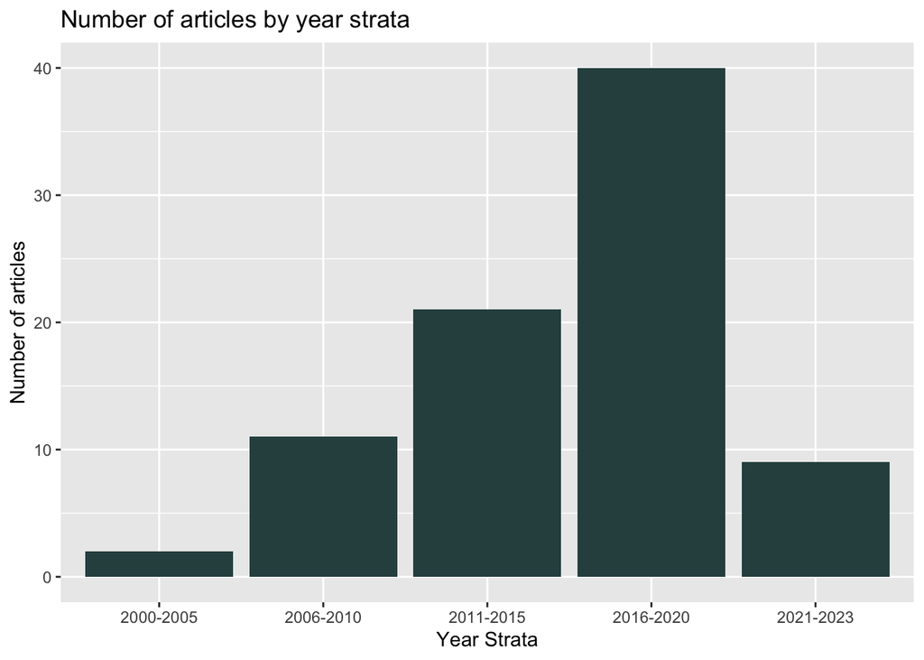

## Publication journals

| Journal | Articles |
| --- | --- |
| Ecology | 7 |
| Biological conservation | 6 |
| Plos One | 6 |
| Conservation biology | 4 |
| Ornithological applications | 4 |
| Ecological applications | 3 |
| Ecosphere | 3 |
| Journal of applied ecology | 3 |
| Landscape ecology | 3 |
| Avian conservation and ecology | 2 |

[output cut: 38 more lines]

## Authorship countries

Counting by the location of the first author’s institution, 15 countries are represented in the sample. A strong majority of articles were published by first authors based in the United States of America.

| FirstAuthor | Articles |
| --- | --- |
| United States of America | 53 |
| United Kingdom | 4 |
| Brazil | 4 |
| Italy | 3 |
| Australia | 3 |
| France | 3 |
| Norway | 2 |
| India | 2 |
| Canada | 2 |
| South Africa | 2 |

[output cut: 5 more lines]

## Authorship categories

| Category | Articles | Proportion |
| --- | --- | --- |
| Academic | 72 | 0.86 |
| Government | 39 | 0.46 |
| NGO | 21 | 0.25 |
| Private | 5 | 0.06 |

There is limited discernible change in authorship categories over time.

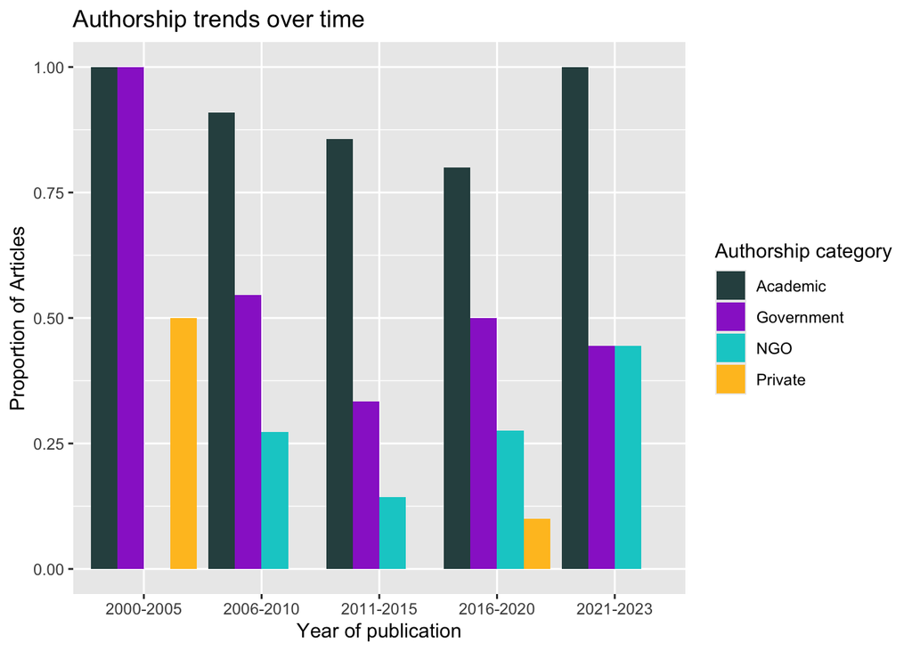

# Objectives and inference

The stated objectives for each article were assessed and divided into four categories - each paper could fall into multiple (or zero) objective categories.

| Objective | Description |
| --- | --- |
| Methods | Did authors seek to demonstrate or test specific methods for occupancy modelling? |
| Future Predictions | Did authors make predictions beyond the study period? |
| Spatial Predictions | Did authors make predictions at locations where surveys were not conducted? |
| Hypothesis testing | Did authors seek to test specific hypotheses of species occupancy dynamics? |

## Frequency of objectives

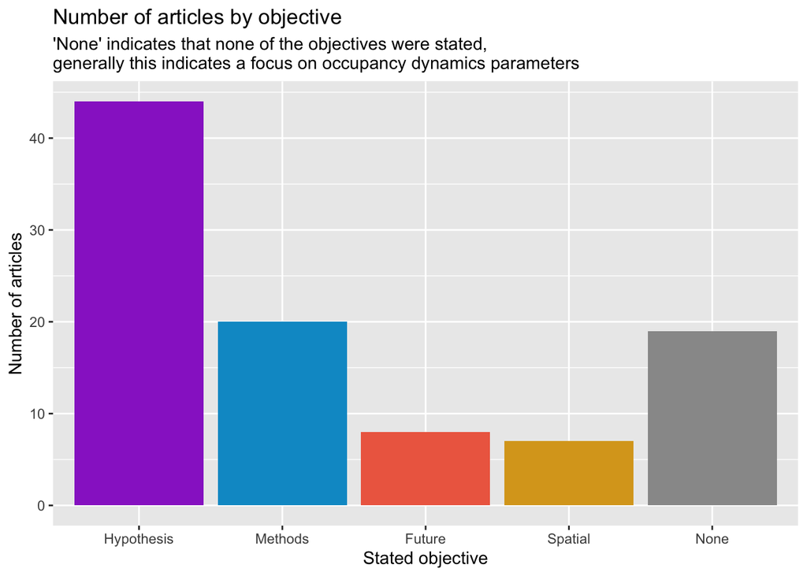

## Stated objectives by authorship categories

Little variation was shown between the objectives of papers by different authorship categories.

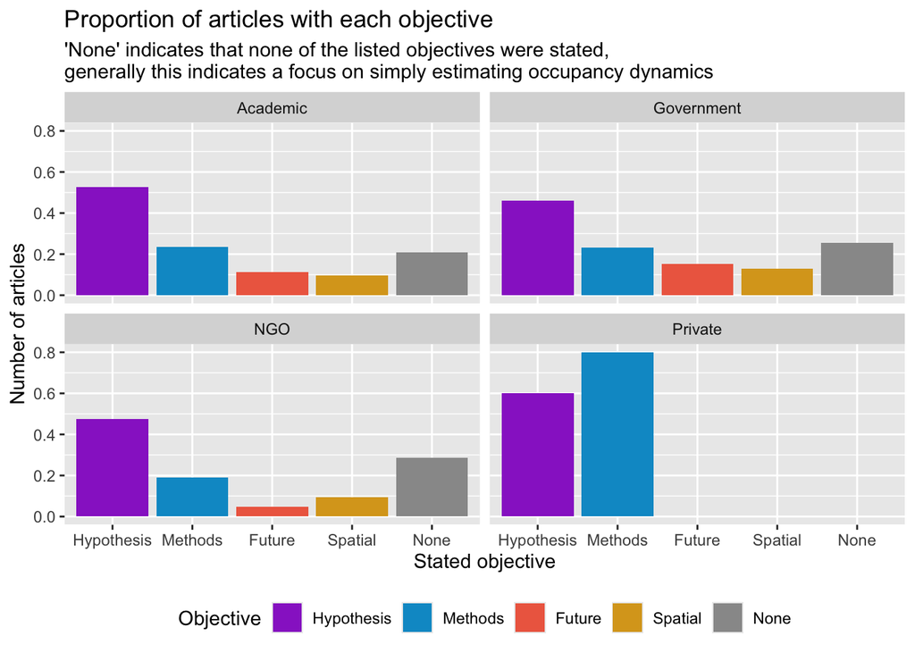

## Stated objective by year

Objective categories have changed in frequency over time, with more variation in objectives in recent years relative to the early days of DOMs

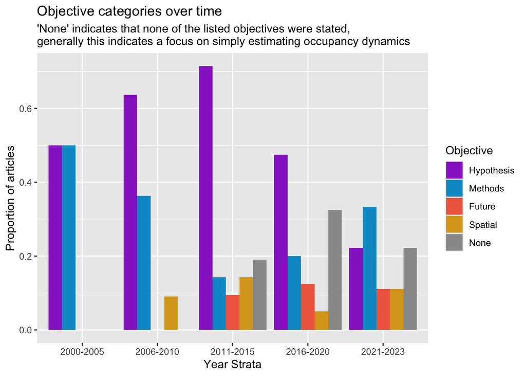

# Species and location

Data on focal species and the location of study areas was collected, available fields include:

| Field | Description | Possible values |
| --- | --- | --- |
| Taxa category | Category of study taxa; could fit into multiple categories | *Bird, Mammal, Invertebrate, Herptile, Fish, Threatened, Invasive, Other* |
| Taxa number | Number of individual species within the taxa for which models were fit | *Numeric* |
| IUCN status | IUCN status for the study species; NA if multi-species or if the study species is invasive | *LC, NT, EN, CR, DD, NA* |
| Threat category | Category of threats to the species; multiple per species permitted | *Habitat loss, Climate change, Exploitation, Invasives, Disease, Disaster, Other* |
| Country | Country/countries where the study took place | *ISO 3166 country names* |
| Continent | Continent(s) where the study took place | *North America, South America, Europe, Asia, Africa, Oceania* |
| Realm | Biogeographic realm where the study took place | *Nearctic, Palearctic, Afrotropical, Indomalayan, Australasian, Neotropical* |
| Size | Size of the study area extent in square kilometres | *<1km, 1-10, 10-100, 100-1000, 10000-100000, 100000-1000000, 1000000+* |

## Taxa categories

DOMs have been widely used for terrestrial taxa, with numerous examples modelling bird, mammal, and herptile occupancy dynamics. 27 articles described their focal species as threatened in some way; 9 fit models to invasive species.

| Taxa | Articles | Percentage |
| --- | --- | --- |
| Bird | 41 | 48 |
| Threatened | 27 | 32 |
| Mammal | 22 | 26 |
| Herptile | 16 | 19 |
| Invasive | 9 | 11 |
| Invertebrate | 5 | 6 |
| Lichen | 1 | 1 |

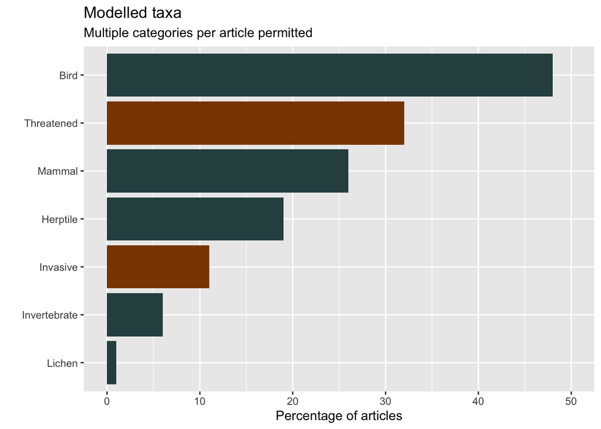

## Threats to modelled taxa

Of papers which describe any threats to their focal taxa, by far the most frequent threat was habitat loss.

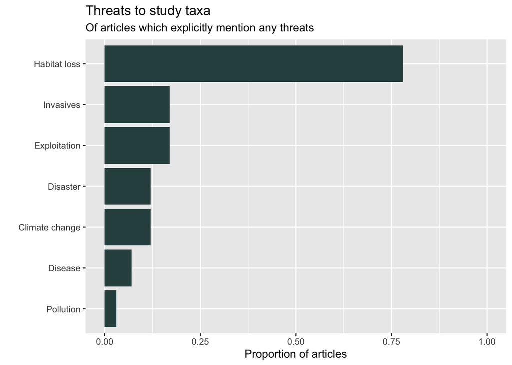

## Threatened taxa

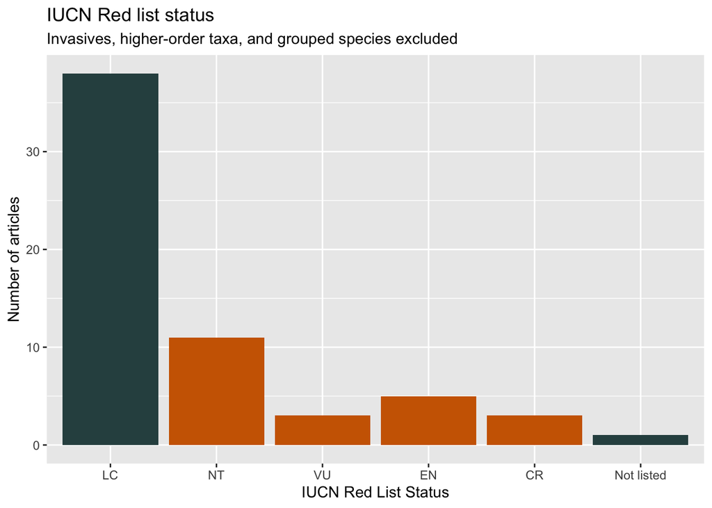

## Number of species

Only approximately half of articles modelled occupancy dynamics for a single taxa. Others fit multiple occupancy models: either multi-species models where 2+ taxa were modelled in concert, or many independent models fit for a suite of taxa. The largest number of species modelled in a single paper was **336**.

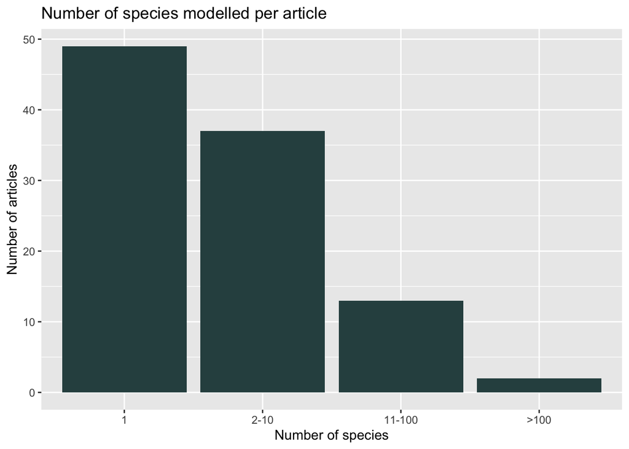

## Study locations

Consistent with authorship trends, a majority of articles conducted studies in the United States.

**Country**

| Country | Articles |
| --- | --- |
| United States of America | 48 |
| India | 4 |
| Brazil | 4 |
| United Kingdom | 3 |
| Switzerland | 3 |
| Italy | 3 |
| Australia | 3 |
| South Africa | 3 |
| Norway | 2 |
| Costa Rica | 2 |

[output cut: 11 more lines]

**Continent**

| Continent | Articles |
| --- | --- |
| North America | 54 |
| Europe | 16 |
| Asia | 5 |
| South America | 5 |
| Oceania | 3 |
| Africa | 3 |

**Realm**

| Realm | Articles |
| --- | --- |
| Nearctic | 47 |
| Palearctic | 15 |
| Neotropical | 13 |
| Indomalayan | 5 |
| Australasian | 3 |
| Afrotropical | 3 |

## Study area size

The size of the study area in square kilometres follows a log-normal distribution, with studies ranging from less than one to over one million square kilometres.

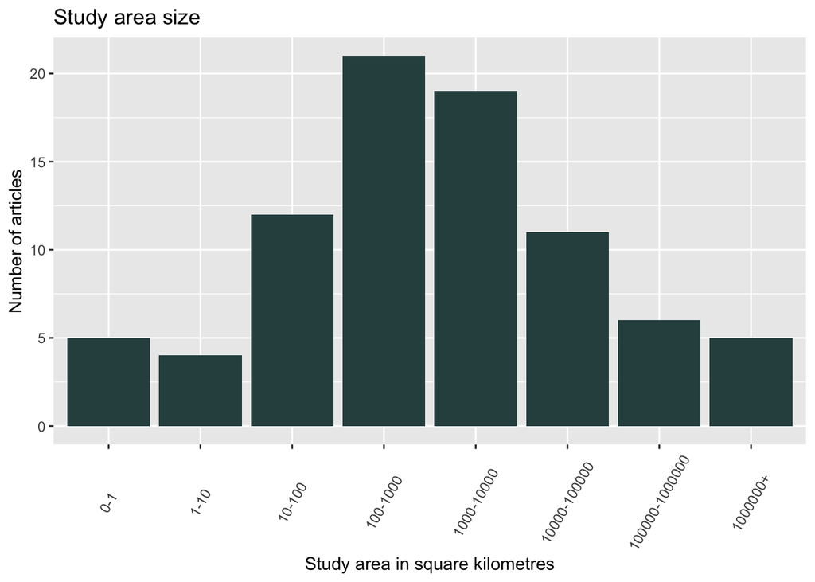

# Data collection

| Field | Description | Possible values |
| --- | --- | --- |
| Duration | Length of study in months | *Numeric* |
| Capture method | Method of recording detections; multiple categories possible | *Audiovisual, Search, Trapping, Bioacoustic, Camera, Citizen, Incidental* |
| Primary occasions | Number of primary occasions | *Numeric* |
| Secondary occasions | Number of secondary occasions, presented as a range where not consistent | *Numeric range* |
| Secondary type | Type of secondary occasion | *Revisits, Spatial replicates, Same-visit replicates, multiple observers, time to detection* |
| Type of site | How a ‘site’ was defined | *Point location, Grid cell, Irregular area, Transect* |
| Number of sites | Number of individual sites | Numeric |
| Sampling method | How sites were selected | *Random, Stratified, Grid, Preferential, Available, Exhaustive, Uniform, Transect* |

## Study duration

Study duration, defined as the length of time between the first and last survey, ranged from **1** month to **40** years, with a median of **47** months.

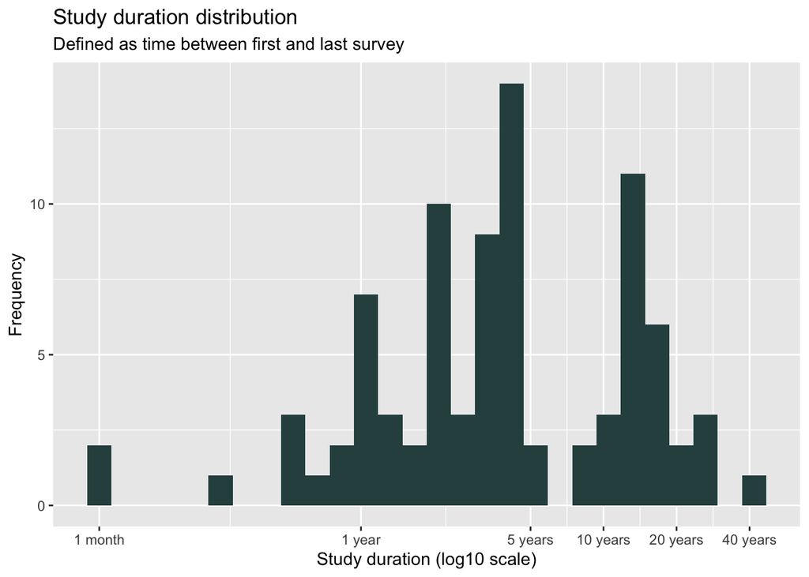

## Number of occasions

The number of sampling occasions varied considerably. The number of primary occasions ranged from just **2** to **204** with a median of **5**.

The number of secondary occasions from **1** to **153** with a median of **5**.

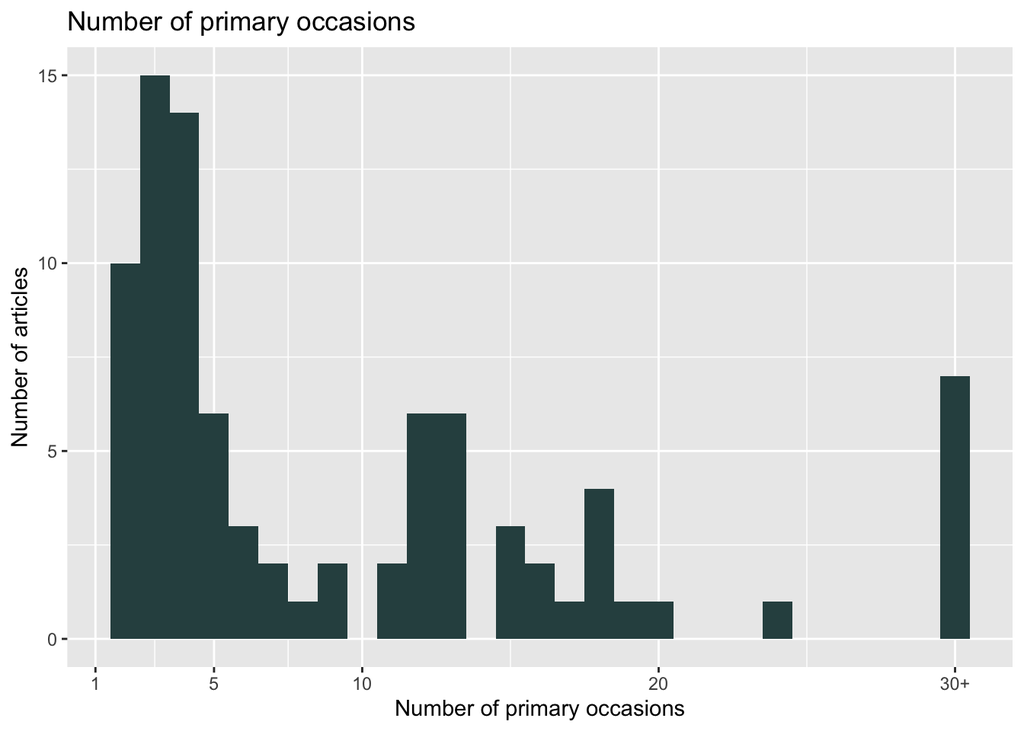

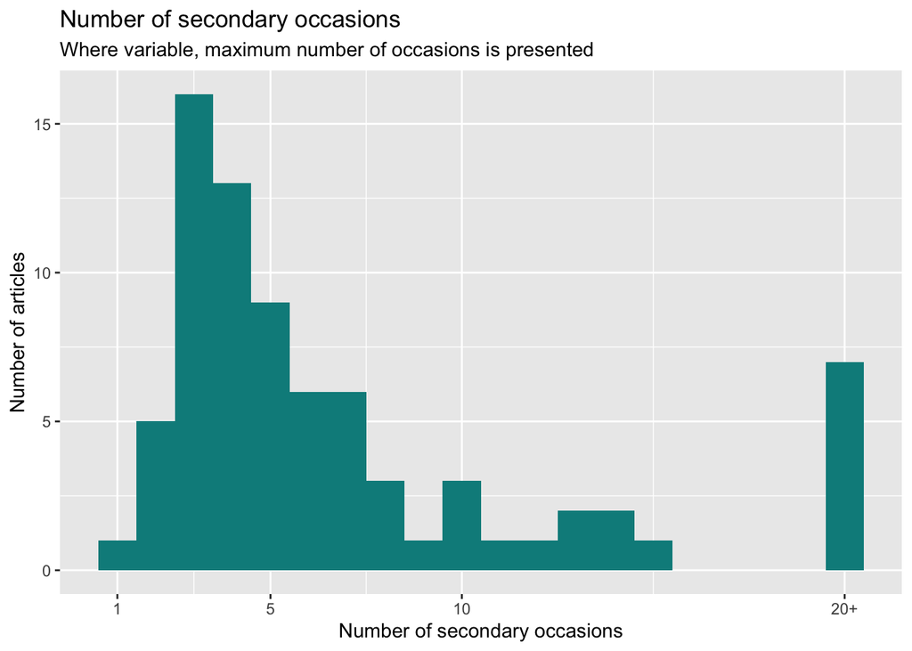

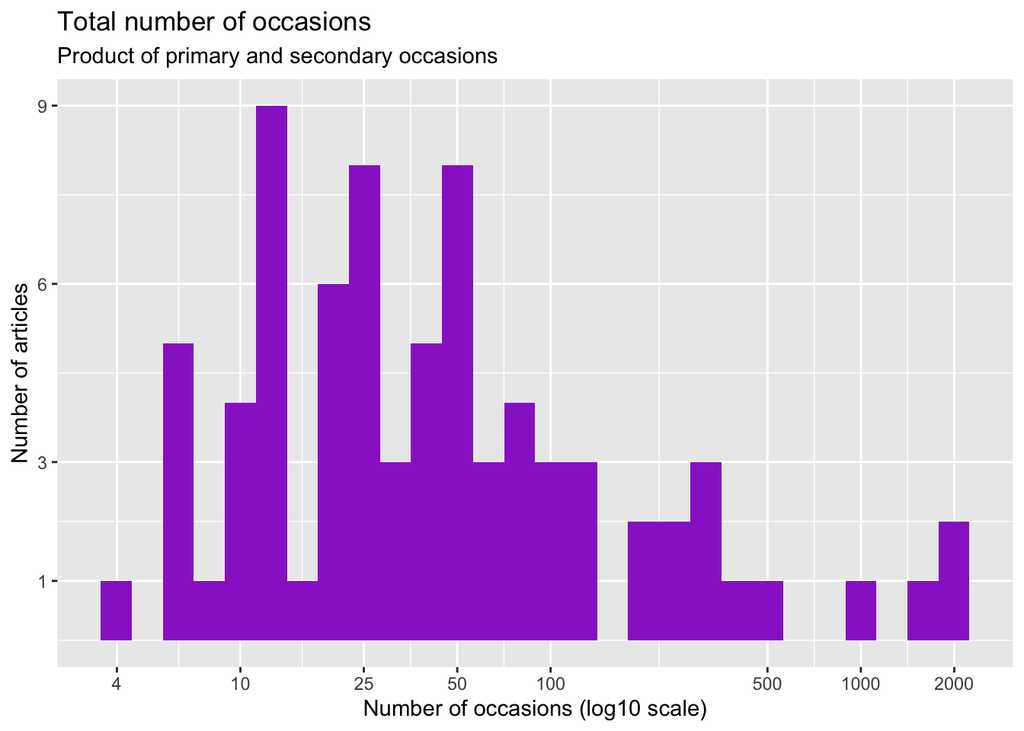

## Data collection method

The most common method for recording detections was human surveys, either structured (e.g. time-bound point counts or transects) or unstructured (searches of sites). Autonomous detection methods (camera traps & acoustic monitors) were used infrequently, despite their potential suitability.

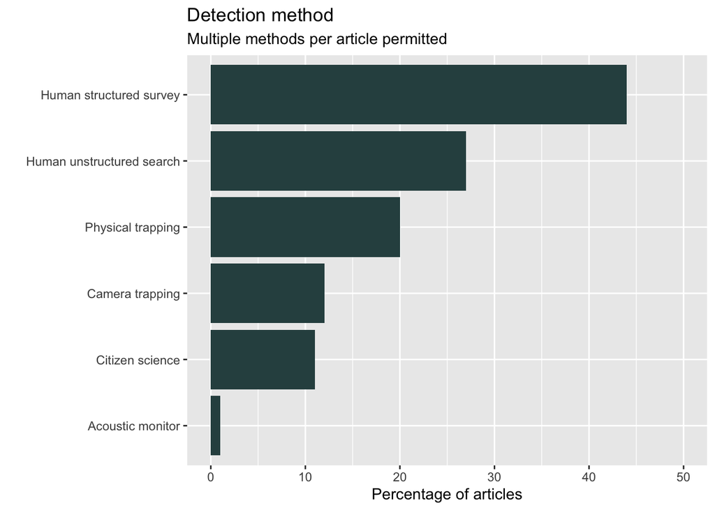

## Number of sites

The number of sites where surveys were conducted ranged widely from **7** to **9394**, with a median site count of **98**.

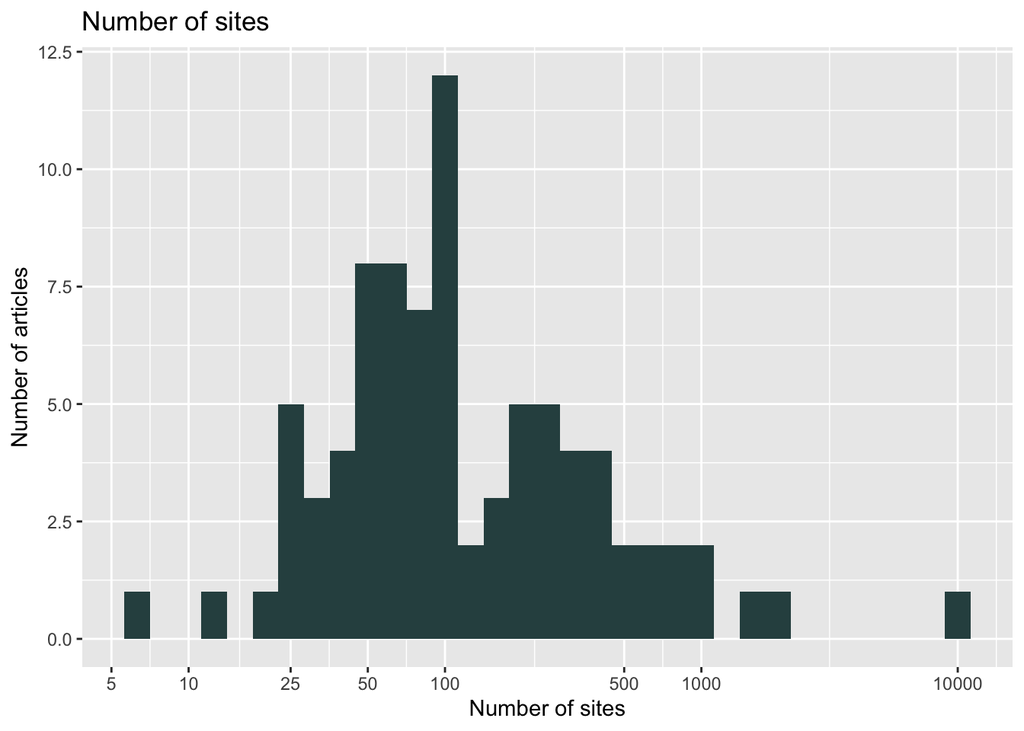

## Sampling method

Site selection was variable; various studies selected sites randomly, as part of a grid design, preferentially, or exhaustively. A considerable amount did not clearly specify how their study sites were determined.

| Sampling_Method | Articles | Percentage |
| --- | --- | --- |
| Random | 22 | 26 |
| Not specified | 19 | 23 |
| Grid | 18 | 21 |
| Preferential | 15 | 18 |
| Stratified | 15 | 18 |
| Exhaustive | 13 | 15 |
| Available | 13 | 15 |
| Transect | 4 | 5 |
| Other | 3 | 4 |
| Unclear | 2 | 2 |

## Study size over time

There does not appear to be a discernible trend in study size (whether defined by duration, number of sites, or total number of survey occasions.

**Year**

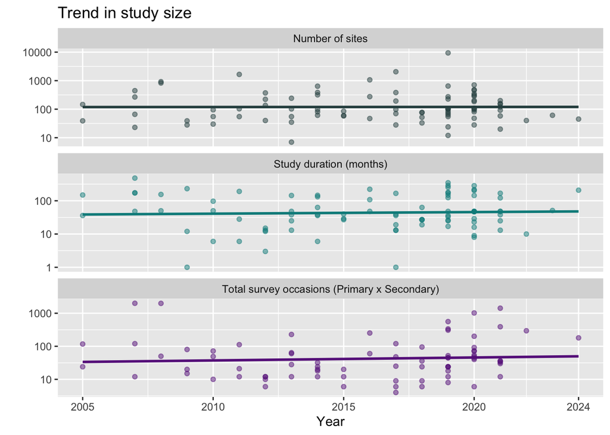

**Year Strata**

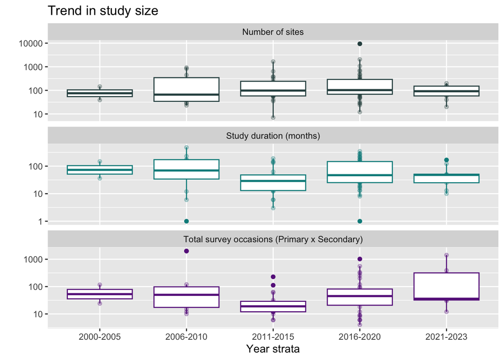

# Covariates

All covariates considered for modelling were documented for each article. Details available for each covariate include:

| Field | Description | Possible values |
| --- | --- | --- |
| Parameter | Parameter which this covariate was considered | *Initial occupancy, colonisation, extinction, detection* |
| Type | Category of covariate | *Environmental: Habitat type terrestrial, Habitat type aquatic, Anthropogenic, Topographic, Climate and weather, Disaster and disturbance, Hydrologic, Seasonality* *Other: Interactions, Site geometry,… |
| Variation | Level of variation for the covariate | *Site, Season, Survey* |
| Measurement | How the covariate was recorded | *Remotely, Observed, Intrinsic* |
| Complexity | How the covariate was mathmatically implemented | *Linear-only, Quadratics, Interactions, Interactions and Quadratics, Other* |

## Covariate quantity

**Overall**

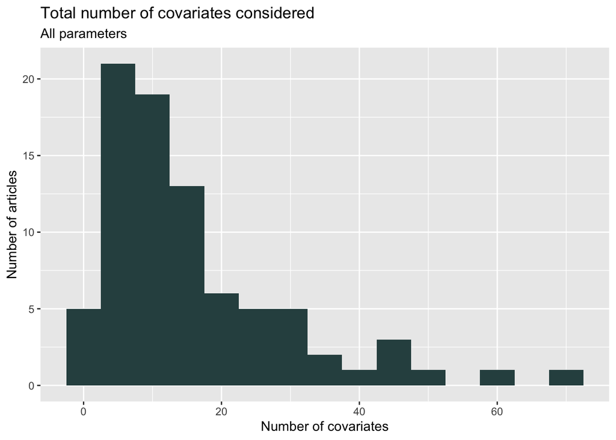

**By parameter**

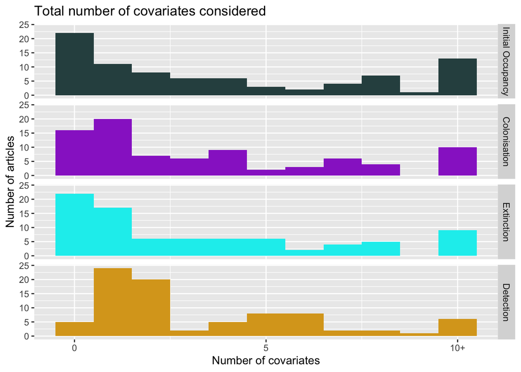

# Modelling

Key details of the modelling process were documented.

| Field | Description | Possible values |
| --- | --- | --- |
| Bayesian | Whether the models fit were Bayesian | *Logical* |
| Prefiltering | Which, if any, prefiltering method was used | *Expert, Simple, Other* |
| Selection | Which, if any, selection method was used | *Single a priori, Multiple a priori, Exhaustive, Exhaustive by parameter, Forwards, Backwards* |
| Evaluation | How models were compared and evaluated | *AIC, AUC, DiC, Model-averaging, Bootstrapping* |
| Multi-species | Whether this was a multi-species model | *Logical* |
| Connectivity | Whether site connectivity was incorporated into the model | *Logical* |